# ANSWERS: Working with untidy and tidy data

Data Science for Biologists, Spring 2020

Nicholas Paterna

# Questions

#### Preface Question

Look at the YAML front matter: there is something NEW! Read about params [here](https://rmarkdown.rstudio.com/lesson-6.html). In this case we set a global parameter for the RMarkdown file that corresponds to the path where data lives! We can proceed to use this as a variable like so (always `params$`, like a column in a data frame!). Use this variable for your paths, e.g. `read_csv(paste0(params$data_path, <NAMEOFFILE>))`

```r
params$data_path
```

```
## [1] "data/"
```

#### Question 1

```r
# Code chunk to read in and examine the data with head()
measles <- read_csv(paste0(params$data_path, "mcv_immunized_percent_of_one_year_olds.csv"))
#Reads in the file we want.
head(measles)
```

```
## # A tibble: 6 x 33
##   country `1980` `1981` `1982` `1983` `1984` `1985` `1986` `1987` `1988` `1989`
##   <chr>    <dbl>  <dbl>  <dbl>  <dbl>  <dbl>  <dbl>  <dbl>  <dbl>  <dbl>  <dbl>
## 1 Afghan…     11     NA      8      9     14     14     14     31     34     22
## 2 Albania     90     90     93     96     96     96     96     96     96     96
## 3 Algeria     NA     NA     NA     NA     NA     68     67     73     81     82
## 4 Andorra     NA     NA     NA     NA     NA     NA     NA     NA     NA     NA
## 5 Angola      NA     NA     NA     26     35     44     44     55     56     48
## 6 Antigu…     NA     NA     NA     48     73     69     80     89     95     95
## # … with 22 more variables: `1990` <dbl>, `1991` <dbl>, `1992` <dbl>,
## #   `1993` <dbl>, `1994` <dbl>, `1995` <dbl>, `1996` <dbl>, `1997` <dbl>,
## #   `1998` <dbl>, `1999` <dbl>, `2000` <dbl>, `2001` <dbl>, `2002` <dbl>,
## #   `2003` <dbl>, `2004` <dbl>, `2005` <dbl>, `2006` <dbl>, `2007` <dbl>,
## #   `2008` <dbl>, `2009` <dbl>, `2010` <dbl>, `2011` <dbl>
```

```r
#OR READ IN THE FILE THIS WAY

file.path(params$data_path, "mcv_immunized_percent_of_one_year_olds.csv") -> name_of_file
measles <- read_csv(name_of_file)
head(measles)
```

```
## # A tibble: 6 x 33
##   country `1980` `1981` `1982` `1983` `1984` `1985` `1986` `1987` `1988` `1989`
##   <chr>    <dbl>  <dbl>  <dbl>  <dbl>  <dbl>  <dbl>  <dbl>  <dbl>  <dbl>  <dbl>
## 1 Afghan…     11     NA      8      9     14     14     14     31     34     22
## 2 Albania     90     90     93     96     96     96     96     96     96     96
## 3 Algeria     NA     NA     NA     NA     NA     68     67     73     81     82
## 4 Andorra     NA     NA     NA     NA     NA     NA     NA     NA     NA     NA
## 5 Angola      NA     NA     NA     26     35     44     44     55     56     48
## 6 Antigu…     NA     NA     NA     48     73     69     80     89     95     95
## # … with 22 more variables: `1990` <dbl>, `1991` <dbl>, `1992` <dbl>,
## #   `1993` <dbl>, `1994` <dbl>, `1995` <dbl>, `1996` <dbl>, `1997` <dbl>,
## #   `1998` <dbl>, `1999` <dbl>, `2000` <dbl>, `2001` <dbl>, `2002` <dbl>,
## #   `2003` <dbl>, `2004` <dbl>, `2005` <dbl>, `2006` <dbl>, `2007` <dbl>,
## #   `2008` <dbl>, `2009` <dbl>, `2010` <dbl>, `2011` <dbl>
```

```r
# Code chunk to convert data to tidy
measles %>%
  pivot_longer(`1980`:`2011`, names_to = "year",
               values_to = "percent") -> tidy_measles
#Combines all the years into a single column, much tidier.
  head(tidy_measles)
```

```
## # A tibble: 6 x 3
##   country     year  percent
##   <chr>       <chr>   <dbl>
## 1 Afghanistan 1980       11
## 2 Afghanistan 1981       NA
## 3 Afghanistan 1982        8
## 4 Afghanistan 1983        9
## 5 Afghanistan 1984       14
## 6 Afghanistan 1985       14
```

#### Question 2

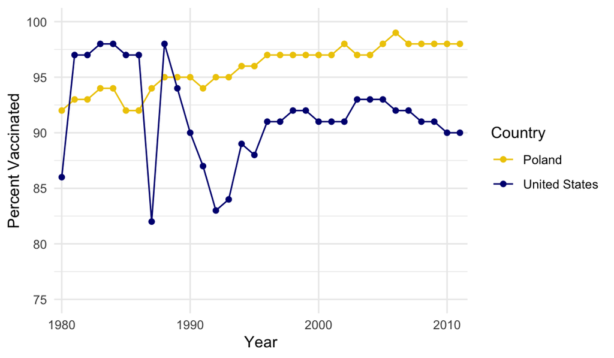

```r
# Code chunk to plot the data
tidy_measles %>%
  group_by(country) %>%
  filter(country %in% c("United States", "Poland")) %>%
#Specifies which countries I want to look at.
  ggplot(aes(x = year, y = percent, color = country, group = country)) +
  geom_point() + geom_line() +
  scale_x_discrete(breaks = c('1980', '1990', '2000', '2010')) +
#Changes the years which will appear on the x-axis.
  ylim(75, 100) +
#Adjusts the limits of the y-axis.
  labs(x = "Year", y = "Percent Vaccinated", color = "Country") +
  scale_color_manual(values = c("gold2", "navyblue")) +
  theme_minimal()
```

It appears that the United States, while reamining mostly vaccinated, fluctuated most bewteen 1980 and 1995. Poland remained consistent and also gradually approached 100%. Altogether, these vaccination rates remained well above 70% for this age group.

#### Question 3

```r
# Code chunk to read in and examine the data with head()
DTP <- read_csv(paste0(params$data_path, "dtp3_immunized_percent_of_one_year_olds.csv")) #Reads in the file we want.
head(DTP)
```

```
## # A tibble: 6 x 33
##   country `1980` `1981` `1982` `1983` `1984` `1985` `1986` `1987` `1988` `1989`
##   <chr>    <dbl>  <dbl>  <dbl>  <dbl>  <dbl>  <dbl>  <dbl>  <dbl>  <dbl>  <dbl>
## 1 Afghan…      4      3      5      5     16     15     11     25     35     33
## 2 Albania     94     94     95     95     95     96     96     96     96     94
## 3 Algeria     NA     NA     NA     NA     NA     69     73     79     85     87
## 4 Andorra     NA     NA     NA     NA     NA     NA     NA     NA     NA     NA
## 5 Angola      NA     NA     NA      6      8      8     10     10     12     18
## 6 Antigu…     54     79     79     99     94     99     96     97     98     99
## # … with 22 more variables: `1990` <dbl>, `1991` <dbl>, `1992` <dbl>,
## #   `1993` <dbl>, `1994` <dbl>, `1995` <dbl>, `1996` <dbl>, `1997` <dbl>,
## #   `1998` <dbl>, `1999` <dbl>, `2000` <dbl>, `2001` <dbl>, `2002` <dbl>,
## #   `2003` <dbl>, `2004` <dbl>, `2005` <dbl>, `2006` <dbl>, `2007` <dbl>,
## #   `2008` <dbl>, `2009` <dbl>, `2010` <dbl>, `2011` <dbl>
```

```r
# Code chunk to convert data to tidy and combine with question 1 data
DTP %>%
  pivot_longer(`1980`:`2011`, names_to = "year",
               values_to = "percent") %>%
  mutate(vaccine = "DTP") -> tidy_DTP
#Performing the same tidying that we did with the measles dataset.
  head(tidy_DTP)
```

```
## # A tibble: 6 x 4
##   country     year  percent vaccine
##   <chr>       <chr>   <dbl> <chr>
## 1 Afghanistan 1980        4 DTP
## 2 Afghanistan 1981        3 DTP
## 3 Afghanistan 1982        5 DTP
## 4 Afghanistan 1983        5 DTP
## 5 Afghanistan 1984       16 DTP
## 6 Afghanistan 1985       15 DTP
```

```r
tidy_measles %>%
  mutate(vaccine = "measles") -> tidy_measles2
#Creating new column so that the combination will be successful, otherwise these values would not be disguised clearly.

bind_rows(tidy_measles2, tidy_DTP) %>%
  mutate(year = as.numeric(year)) -> tidy_vaccines
#Changes year from a CHARACTER to a NUMERIC.
head(tidy_vaccines)
```

```
## # A tibble: 6 x 4
##   country      year percent vaccine
##   <chr>       <dbl>   <dbl> <chr>
## 1 Afghanistan  1980      11 measles
## 2 Afghanistan  1981      NA measles
## 3 Afghanistan  1982       8 measles
## 4 Afghanistan  1983       9 measles
## 5 Afghanistan  1984      14 measles
## 6 Afghanistan  1985      14 measles
```

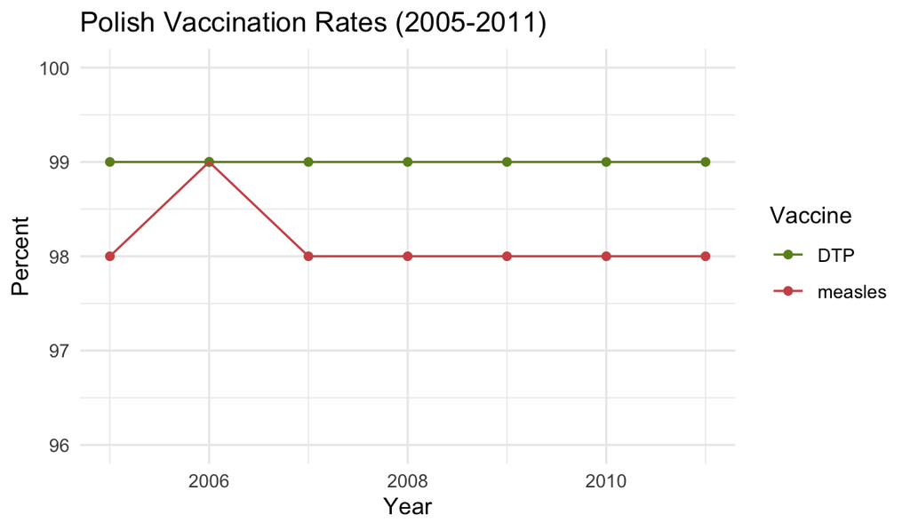

```r
# Code chunk to plot the data
tidy_vaccines %>%
  filter(country == "Poland") %>%
  filter(between(year, 2005, 2021)) %>%
#This determines the country and year that we are including in the figure.
  ggplot(aes(x = year, y = percent, color = vaccine)) +
  geom_point() + geom_line() +
#I want to connect the points so both geoms are required for this.
  scale_color_manual(values = c("olivedrab", "indianred3")) +
  ylim(96, 100) +
#Adjusting the limits of the y-axis makes the data easier to visualize.
  labs(x = "Year", y = "Percent",
       color = "Vaccine", title = "Polish Vaccination Rates (2005-2011)") +
  theme_minimal()
```

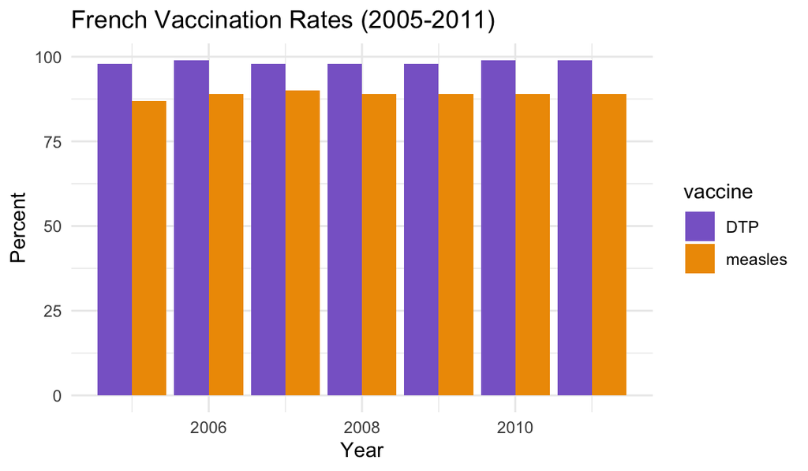

```r
tidy_vaccines %>%
  filter(country == "France") %>%
  filter(between(year, 2005, 2021)) %>%
#This determines the country and year that we are including in the figure.
  ggplot(aes(x = year, y = percent, fill = vaccine)) +
  geom_col(position = "dodge") +
#Using this argument separates the bars and puts them alongside eachother.
  scale_fill_manual(values = c("mediumpurple3", "orange2")) +
  labs(x = "Year", y = "Percent",
       color = "Vaccine", title = "French Vaccination Rates (2005-2011)") +
  theme_minimal()
```

I decided to utilized both methods of visualization with two different countries, I found that the line plot is much easier to read! Additionally, during this time period in both western European countries the vaccination rate for measles and DTP was near 100%. Herd immunity is awesome!

#### Question 4

```r
# Code chunk to read in and examine the data with head()
seals <- read_csv(paste0(params$data_path, "seals.csv")) #Reads in the file we want.
head(seals)
```

```
## # A tibble: 6 x 3
##    seal feeding oxygen_use
##   <dbl> <chr>        <dbl>
## 1     1 No            42.2
## 2     1 Yes           71
## 3     2 No            51.7
## 4     2 Yes           77.3
## 5     3 No            82.8
## 6     3 Yes           78.6
```

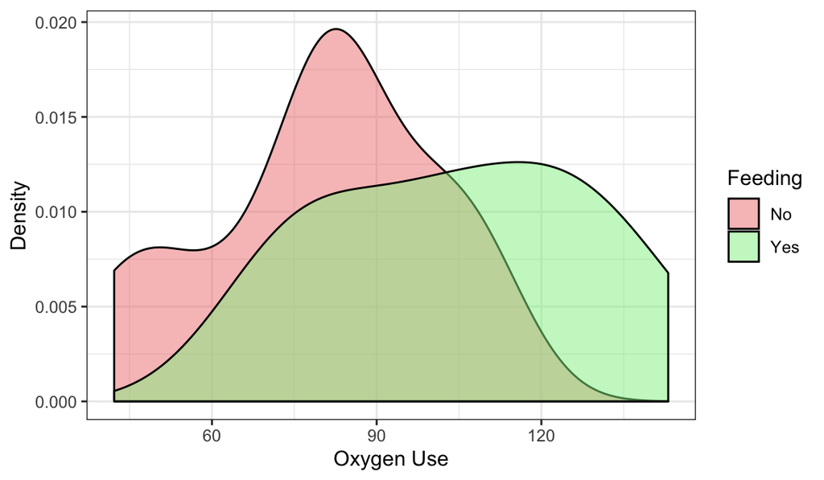

```r
# Code chunk for distributions (violin, sina, etc.)
# If sina make sure to load `ggforce()` in SETUP CHUNK!
seals %>%
  ggplot(aes(x = oxygen_use, fill = feeding)) +
  geom_density(alpha = 0.5) +
#It is important to include an alpha so the two peaks can be easily visualized.
  scale_fill_manual(values = c("lightcoral", "lightgreen")) +
  labs(x = "Oxygen Use", y = "Density", fill = "Feeding")
```

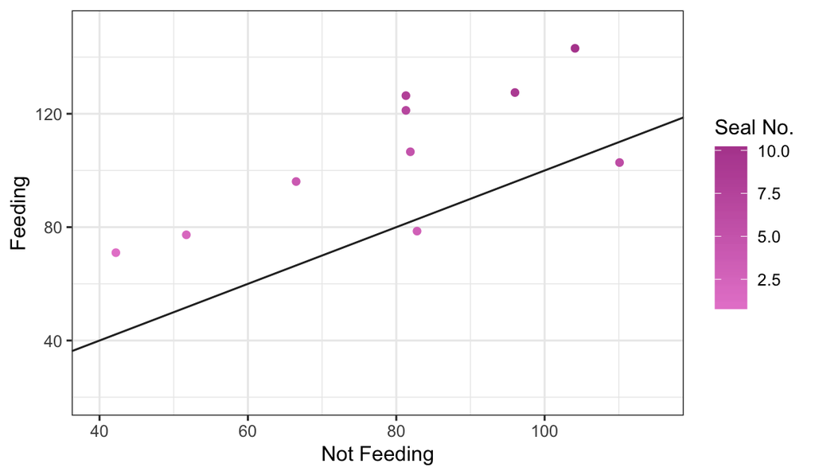

```r
# Code chunk for data un-tidying and scatterplot
seals %>%
  pivot_wider(names_from = "feeding",
              values_from = "oxygen_use") -> untidy_seals

untidy_seals %>%
  ggplot(aes(x = No, y = Yes)) +
  geom_point(aes(color = seal)) +
  scale_color_gradient(low = "#e687d0", high = "#b54c9d") +
  geom_abline(color = "gray16") +
  xlim(40,115) +
  ylim(20,150) +
#Adjusting the limits of both axes make the data easily visualized.
  labs(x = "Not Feeding", y = "Feeding", color = "Seal No.")
```

In the original density plot it is difficult to determine whether there is a positive relationship between feeding and oxygen use from the seals, but using the scatter plot it is clear that this relationship does exist. As the seals feed their oxygen use is increased.

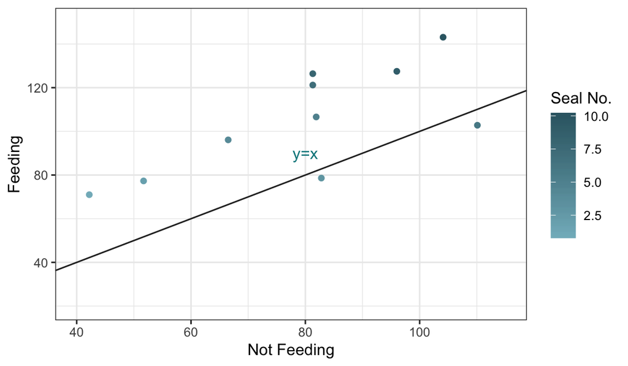

```r
untidy_seals %>%
  ggplot(aes(x = No, y = Yes)) +
  geom_point(aes(color = seal)) +
  scale_color_gradient(low = "#82b7c4", high = "#366773") +
  geom_abline(color = "gray16") +
  annotate("text", x = 80, y = 90,
           label = "y=x", color = "turquoise4") +
#Added the text to the trendline on the graph, chose positioning and color.
  xlim(40,115) +
  ylim(20,150) +
  labs(x = "Not Feeding", y = "Feeding", color = "Seal No.")
```

#### Question 5

```r
# Code chunk to read in and examine the data with head()
planets <- read_delim(delim = ";",
#Using read_delim() allows me to describe how the file is delimitted before converting it to a tibble in my RStudio.
                      paste0(params$data_path, "planets.csv"))
head(planets)
```

```
## # A tibble: 6 x 10
##   name  rotation_period orbital_period diameter climate gravity terrain
##   <chr>           <dbl>          <dbl>    <dbl> <chr>   <chr>   <chr>
## 1 Alde…              24            364    12500 temper… 1 stan… grassl…
## 2 Yavi…              24           4818    10200 temper… 1 stan… jungle…
## 3 Hoth               23            549     7200 frozen  1.1 st… tundra…
## 4 Dago…              23            341     8900 murky   N/A     swamp,…
## 5 Besp…              12           5110   118000 temper… 1.5 st… gas gi…
## 6 Endor              18            402     4900 temper… 0.85 s… forest…
## # … with 3 more variables: surface_water <chr>, population <chr>, edited <dttm>
```

```r
# Code chunk for tidying

planets %>%
  separate_rows(terrain) %>%
  separate_rows(climate) -> tidy_planets
head(tidy_planets)
```

```
## # A tibble: 6 x 10
##   name  rotation_period orbital_period diameter climate gravity terrain
##   <chr>           <dbl>          <dbl>    <dbl> <chr>   <chr>   <chr>
## 1 Alde…              24            364    12500 temper… 1 stan… grassl…
## 2 Alde…              24            364    12500 temper… 1 stan… mounta…
## 3 Yavi…              24           4818    10200 temper… 1 stan… jungle
## 4 Yavi…              24           4818    10200 tropic… 1 stan… jungle
## 5 Yavi…              24           4818    10200 temper… 1 stan… rainfo…
## 6 Yavi…              24           4818    10200 tropic… 1 stan… rainfo…
## # … with 3 more variables: surface_water <chr>, population <chr>, edited <dttm>
```

```r
# HINT: it's literally just piping data into separate_rows twice, one for the column given in the question, and for the second you need to figure out the column.
## DO NOT OVERCOMPLICATE THIS QUESTION.
```

#### Question 6

```r
# Code chunk for allllll the wrangling and tidying
# should END UP as a single piped command - but build it up LINE AT A TIME!

tidy_planets %>%
  separate(edited, c("edited_date", "edited_time"),sep = " ") %>%
#Splits the edited column into the two specified columns.
  mutate(ratio_period_rotation_orbital = (rotation_period / orbital_period)) %>%
#Creates the new column with the following ratio; rotation_period:orbital_period.
  unite("name_pop", c(name, population), sep = "-") %>%
#Combines the two specified columns into one.
  filter(terrain == "mountains") %>%
#Views only the planets with this type of terrain.
  arrange(desc(ratio_period_rotation_orbital)) -> question_6
#Arranges the filtered data by DESCENDING ratio.
question_6
```

```
## # A tibble: 7 x 11
##   name_pop rotation_period orbital_period diameter climate gravity terrain
##   <chr>              <dbl>          <dbl>    <dbl> <chr>   <chr>   <chr>
## 1 Geonosi…              30            256    11370 temper… 0.9 st… mounta…
## 2 Geonosi…              30            256    11370 arid    0.9 st… mounta…
## 3 Naboo-4…              26            312    12120 temper… 1 stan… mounta…
## 4 Alderaa…              24            364    12500 temper… 1 stan… mounta…
## 5 Corusca…              24            368    12240 temper… 1 stan… mounta…
## 6 Endor-3…              18            402     4900 temper… 0.85 s… mounta…
## 7 Hoth-un…              23            549     7200 frozen  1.1 st… mounta…
## # … with 4 more variables: surface_water <chr>, edited_date <chr>,
## #   edited_time <chr>, ratio_period_rotation_orbital <dbl>
```

#### Question 7

```r
## defines each column as an array
tibble(
  color        = c("blue", "green", "turquoise"),
  male         = c(25, 36, 52),
  female       = c(28, 17, 33),
  species_abbr = c("sp1", "sp1", "sp1")
) -> frogs_sp1
print(frogs_sp1)
```

```
## # A tibble: 3 x 4
##   color      male female species_abbr
##   <chr>     <dbl>  <dbl> <chr>
## 1 blue         25     28 sp1
## 2 green        36     17 sp1
## 3 turquoise    52     33 sp1
```

```r
## defines tibble in a format like the tibble would end up appearing
## spacing is helpful!
tribble(
  ~color, ~male, ~female, ~species_abbr,
  "orange", 13,   17,    "sp2",
  "red",    45,   36,    "sp2",
  "pink",  31,    25,    "sp2"
) -> frogs_sp2
print(frogs_sp2)
```

```
## # A tibble: 3 x 4
##   color   male female species_abbr
##   <chr>  <dbl>  <dbl> <chr>
## 1 orange    13     17 sp2
## 2 red       45     36 sp2
## 3 pink      31     25 sp2
```

```r
## Like strategy one
tibble(
  species_name = c("Frogus firstus", "Frogus secondus"),
  species_abbr = c("sp1", "sp2")
) -> species_names
print(species_names)
```

```
## # A tibble: 2 x 2
##   species_name    species_abbr
##   <chr>           <chr>
## 1 Frogus firstus  sp1
## 2 Frogus secondus sp2
```

```r
### ADD CODE HERE TO PRINT OUT THESE THREE DATASETS!!! YOU HAVE TO LOOK AT THEM TO USE THEM!!
```

```r
# Code chunk to tidy and combine the three datasets
bind_rows(frogs_sp1, frogs_sp2) %>%
#Combines the two datasets containing frog observations.
  inner_join(species_names) %>%
#Using common data (species name & abbr.) to bring in these observations.
  separate(species_name, c("genus", "species"), sep = " ") %>%
#Creates two columns from the single species_name col.
  pivot_longer(male:female,
               names_to = "sex",
               values_to = "number") %>%
#Combines the two male & female cols. into one sex category.
  select(- species_abbr) -> tidy_frogs
#Removes the unwanted species_abbr col.
head(tidy_frogs)
```

```
## # A tibble: 6 x 5
##   color     genus  species sex    number
##   <chr>     <chr>  <chr>   <chr>   <dbl>
## 1 blue      Frogus firstus male       25
## 2 blue      Frogus firstus female     28
## 3 green     Frogus firstus male       36
## 4 green     Frogus firstus female     17
## 5 turquoise Frogus firstus male       52
## 6 turquoise Frogus firstus female     33
```

```r
# Code chunk to for dplyr task 1
tidy_frogs %>%
  filter(sex == "female",
         color %in% c("green", "blue"),
         species == "firstus")
```

```
## # A tibble: 2 x 5
##   color genus  species sex    number
##   <chr> <chr>  <chr>   <chr>   <dbl>
## 1 blue  Frogus firstus female     28
## 2 green Frogus firstus female     17
```

```r
#There are more blue female Frogus firstus frogs than there are green.
```

```r
# Code chunk to for dplyr task 2
tidy_frogs %>%
  filter(sex == "male") %>%
  group_by(species) %>%
  summarize(total_males = sum(number))
```

```
## # A tibble: 2 x 2
##   species  total_males
##   <chr>          <dbl>
## 1 firstus          113
## 2 secondus          89
```

```r
#Frogus firstus has more males than the secondus species.
```

```r
# Code chunk to for dplyr task 3
tidy_frogs %>%
  pivot_wider(names_from = sex,
              values_from = number) %>%
  group_by(color) %>%
  filter(species == "secondus") %>%
  summarize(sex_ratio = (male/female))
```

```
## # A tibble: 3 x 2
##   color  sex_ratio
##   <chr>      <dbl>
## 1 orange     0.765
## 2 pink       1.24
## 3 red        1.25
```

```r
#Red color has the highest ratio of male to female frogs in the secondus species.
```

#### Question 8

```r
# Code chunk for kable()
tidy_frogs %>%
  kable() %>%
  kable_styling(bootstrap_options = c("striped", "hover", "responsive"), position = "center") %>%
  row_spec(1:2, bold = T, color = "white", background = "#4e54ed") %>%
  row_spec(3:4, bold = T, color = "white", background = "#4eab4b") %>%
  row_spec(5:6, bold = T, color = "white", background = "#4baba6") %>%
  row_spec(7:8, bold = T, color = "white", background = "#d9af27") %>%
  row_spec(9:10, bold = T, color = "white", background = "#d92d27") %>%
  row_spec(11:12, bold = T, color = "white", background = "#c22db8")
```

| color | genus | species | sex | number |
| --- | --- | --- | --- | --- |
| blue | Frogus | firstus | male | 25 |
| blue | Frogus | firstus | female | 28 |
| green | Frogus | firstus | male | 36 |
| green | Frogus | firstus | female | 17 |
| turquoise | Frogus | firstus | male | 52 |
| turquoise | Frogus | firstus | female | 33 |
| orange | Frogus | secondus | male | 13 |
| orange | Frogus | secondus | female | 17 |
| red | Frogus | secondus | male | 45 |
| red | Frogus | secondus | female | 36 |
| pink | Frogus | secondus | male | 31 |
| pink | Frogus | secondus | female | 25 |

```r
#Using striped & hover styling techniques the table will be interactive and change the row color if the mouse is hovering over it.

#Using "responsive" argument makes the table friendly on a mobile device, you can now scroll through it.

#Individually colored rows according to frog color using thr row_spec() function.
```

#### BONUS QUESTION

```r
read_csv("hiv_deaths.csv") -> hiv_deaths
head(hiv_deaths)
```

```
## # A tibble: 6 x 23
##   country `1990` `1991` `1992` `1993` `1994` `1995` `1996` `1997` `1998` `1999`
##   <chr>    <dbl>  <dbl>  <dbl>  <dbl>  <dbl>  <dbl>  <dbl>  <dbl>  <dbl>  <dbl>
## 1 Afghan…     60     60     60     60     60    150    150    150    150    150
## 2 Algeria     60     60     60     60     60     60     60     60    120    120
## 3 Angola     600   1200   1800   2500   3300   4300   5300   6300   7300   8200
## 4 Argent…   3000   3200   3400   3600   3800   3500   3200   3100   3000   3000
## 5 Armenia     60     60     60     60     60     60     60     60     60    150
## 6 Austra…    350    600    600    600    600    600    600    350    350    350
## # … with 12 more variables: `2000` <dbl>, `2001` <dbl>, `2002` <dbl>,
## #   `2003` <dbl>, `2004` <dbl>, `2005` <dbl>, `2006` <dbl>, `2007` <dbl>,
## #   `2008` <dbl>, `2009` <dbl>, `2010` <dbl>, `2011` <dbl>
```

```r
hiv_deaths %>%
  pivot_longer(`1990`:`2011`, names_to = "year",
               values_to = "deaths") -> tidy_hiv
head(tidy_hiv)
```

```
## # A tibble: 6 x 3
##   country     year  deaths
##   <chr>       <chr>  <dbl>
## 1 Afghanistan 1990      60
## 2 Afghanistan 1991      60
## 3 Afghanistan 1992      60
## 4 Afghanistan 1993      60
## 5 Afghanistan 1994      60
## 6 Afghanistan 1995     150
```

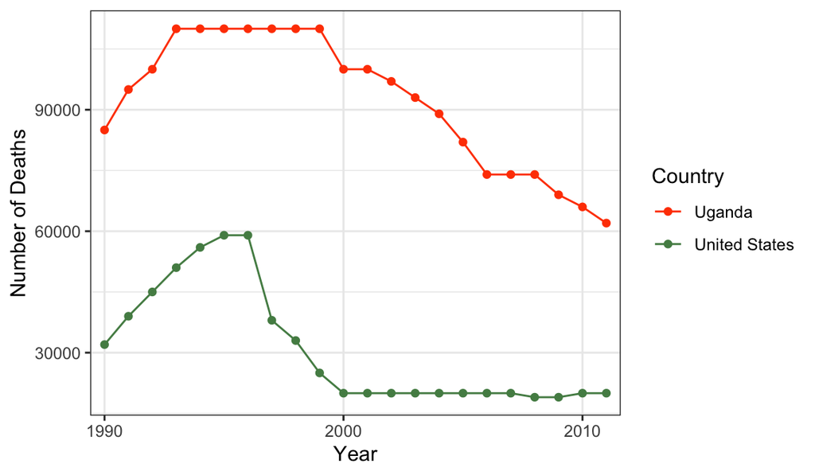

```r
tidy_hiv %>%
  group_by(country) %>%
  filter(country %in% c("United States", "Uganda")) %>%
#Specifies which countries I want to look at.
  ggplot(aes(x = year, y = deaths, color = country, group = country)) +
  geom_point() + geom_line() +
  scale_color_manual(values = c("orangered", "palegreen4")) +
  scale_x_discrete(breaks = c('1990', '2000', '2010')) +
#Changes the years which will appear on the x-axis.
  labs(x = "Year", y = "Number of Deaths", color = "Country")
```